# 1. Importing libraries

```python
import numpy as np
import pandas as pd
import matplotlib.pyplot as plt
import seaborn as sns
```

# 2. Importing dataset

wine_dataset is divided into red_wine_dataset and white_wine_dataset for analysis

```python
dataset_wine = pd.read_csv("wine_dataset.csv")
dataset_red = pd.read_csv("red_wine_dataset.csv")
dataset_white = pd.read_csv("white_wine_dataset.csv")
```

# 3. Assess Data Quality & Missing Values

```python
dataset_wine.head()
```

|  | fixed_acidity | volatile_acidity | citric_acid | residual_sugar | chlorides | free_sulfur_dioxide | total_sulfur_dioxide | density | pH | sulphates | alcohol | quality | style |
| --- | --- | --- | --- | --- | --- | --- | --- | --- | --- | --- | --- | --- | --- |
| 0 | 7.4 | 0.70 | 0.00 | 1.9 | 0.076 | 11.0 | 34.0 | 0.9978 | 3.51 | 0.56 | 9.4 | 5 | red |
| 1 | 7.8 | 0.88 | 0.00 | 2.6 | 0.098 | 25.0 | 67.0 | 0.9968 | 3.20 | 0.68 | 9.8 | 5 | red |
| 2 | 7.8 | 0.76 | 0.04 | 2.3 | 0.092 | 15.0 | 54.0 | 0.9970 | 3.26 | 0.65 | 9.8 | 5 | red |
| 3 | 11.2 | 0.28 | 0.56 | 1.9 | 0.075 | 17.0 | 60.0 | 0.9980 | 3.16 | 0.58 | 9.8 | 6 | red |
| 4 | 7.4 | 0.70 | 0.00 | 1.9 | 0.076 | 11.0 | 34.0 | 0.9978 | 3.51 | 0.56 | 9.4 | 5 | red |

```python
dataset_wine.describe()
```

|  | fixed_acidity | volatile_acidity | citric_acid | residual_sugar | chlorides | free_sulfur_dioxide | total_sulfur_dioxide | density | pH | sulphates | alcohol | quality |
| --- | --- | --- | --- | --- | --- | --- | --- | --- | --- | --- | --- | --- |
| count | 6497.000000 | 6497.000000 | 6497.000000 | 6497.000000 | 6497.000000 | 6497.000000 | 6497.000000 | 6497.000000 | 6497.000000 | 6497.000000 | 6497.000000 | 6497.000000 |
| mean | 7.215307 | 0.339666 | 0.318633 | 5.443235 | 0.056034 | 30.525319 | 115.744574 | 0.994697 | 3.218501 | 0.531268 | 10.491801 | 5.818378 |
| std | 1.296434 | 0.164636 | 0.145318 | 4.757804 | 0.035034 | 17.749400 | 56.521855 | 0.002999 | 0.160787 | 0.148806 | 1.192712 | 0.873255 |
| min | 3.800000 | 0.080000 | 0.000000 | 0.600000 | 0.009000 | 1.000000 | 6.000000 | 0.987110 | 2.720000 | 0.220000 | 8.000000 | 3.000000 |
| 25% | 6.400000 | 0.230000 | 0.250000 | 1.800000 | 0.038000 | 17.000000 | 77.000000 | 0.992340 | 3.110000 | 0.430000 | 9.500000 | 5.000000 |
| 50% | 7.000000 | 0.290000 | 0.310000 | 3.000000 | 0.047000 | 29.000000 | 118.000000 | 0.994890 | 3.210000 | 0.510000 | 10.300000 | 6.000000 |
| 75% | 7.700000 | 0.400000 | 0.390000 | 8.100000 | 0.065000 | 41.000000 | 156.000000 | 0.996990 | 3.320000 | 0.600000 | 11.300000 | 6.000000 |
| max | 15.900000 | 1.580000 | 1.660000 | 65.800000 | 0.611000 | 289.000000 | 440.000000 | 1.038980 | 4.010000 | 2.000000 | 14.900000 | 9.000000 |

```python
dataset_wine.isnull().sum()
```

```
fixed_acidity           0
volatile_acidity        0
citric_acid             0
residual_sugar          0
chlorides               0
free_sulfur_dioxide     0
total_sulfur_dioxide    0
density                 0
pH                      0
sulphates               0
alcohol                 0
quality                 0
style                   0
dtype: int64
```

# 4. Visualize the data

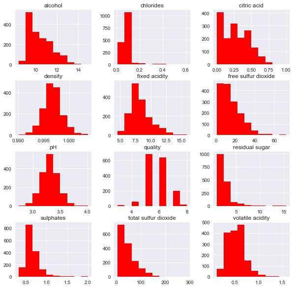

```python
sns.set()
dataset_red.hist(figsize=(10,10), color='red')
plt.show()
```

Observations:

1. Alcohol, residual sugar, free & total sulfur dioxide, chlorides, citric acid level distribution looks skewed.

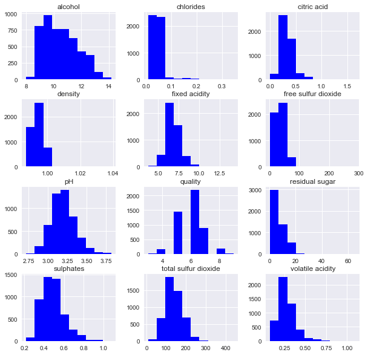

```python
sns.set()
dataset_white.hist(figsize=(10,10), color='blue')
plt.show()
```

Observations:

1. Alcohol, residual sugar, free sulfur dioxide, chlorides, citric acid level distribution looks skewed.

# Correlation Heat Maps for Red & White wine

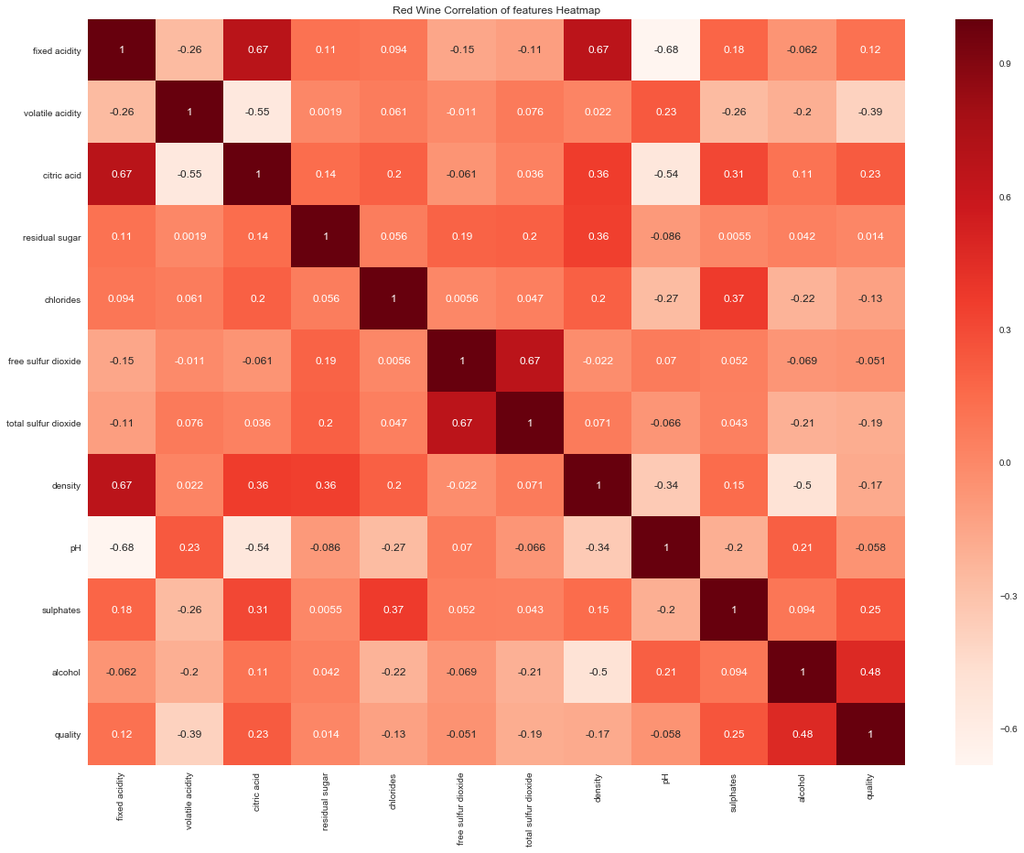

```python
plt.subplots(figsize=(20,15))
ax = plt.axes()
ax.set_title("Red Wine Correlation of features Heatmap")
corr_red = dataset_red.corr()
sns.heatmap(corr_red,
            xticklabels=corr_red.columns.values,
            yticklabels=corr_red.columns.values,
           linecolor='white', cmap="Reds", annot=True)
plt.show()
```

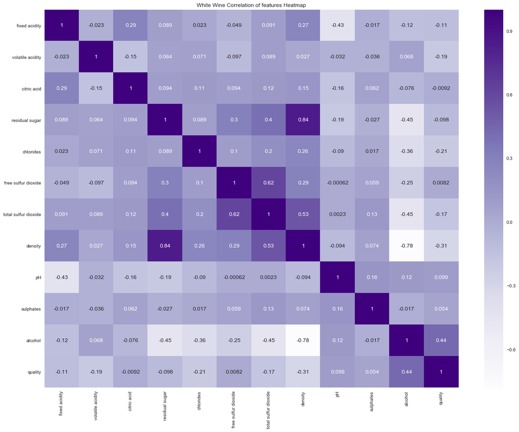

```python
plt.subplots(figsize=(20,15))
ax = plt.axes()
ax.set_title("White Wine Correlation of features Heatmap")
corr_white = dataset_white.corr()
sns.heatmap(corr_white,
            xticklabels=corr_white.columns.values,
            yticklabels=corr_white.columns.values,
           linecolor='white', cmap="Purples", annot=True)
plt.show()
```

Observations regarding white wine:

1. Density and residual sugar are strongly positively correlated (0.84)
2. Alcohol and Density are strongly negatively correlated (-0.78)
3. Total sulfur dioxide and free sulfur dioxide are highly positively correlated (0.62)
4. Density and total Sulfur dioxide are strongly positively correlated (0.53)
5. Alcohol and residual sugar are negatively correlated (-0.45)
6. Alcohol and total sulfur dioxide are negatively correlated (-0.45)
7. Quality and Alcohol are positively correlated (0.44)
8. Fixed acidity and the pH levels are highly negatively correlated. (-0.43) ie. lesser pH means more acidic.
9. Total sulfur dioxide and residual sugar positively correlated (0.4)
10. Alcohol and Chloride are negatively correlated (-0.36)
11. Free sulfur dioxide and residual sugar positively correlated (0.3)

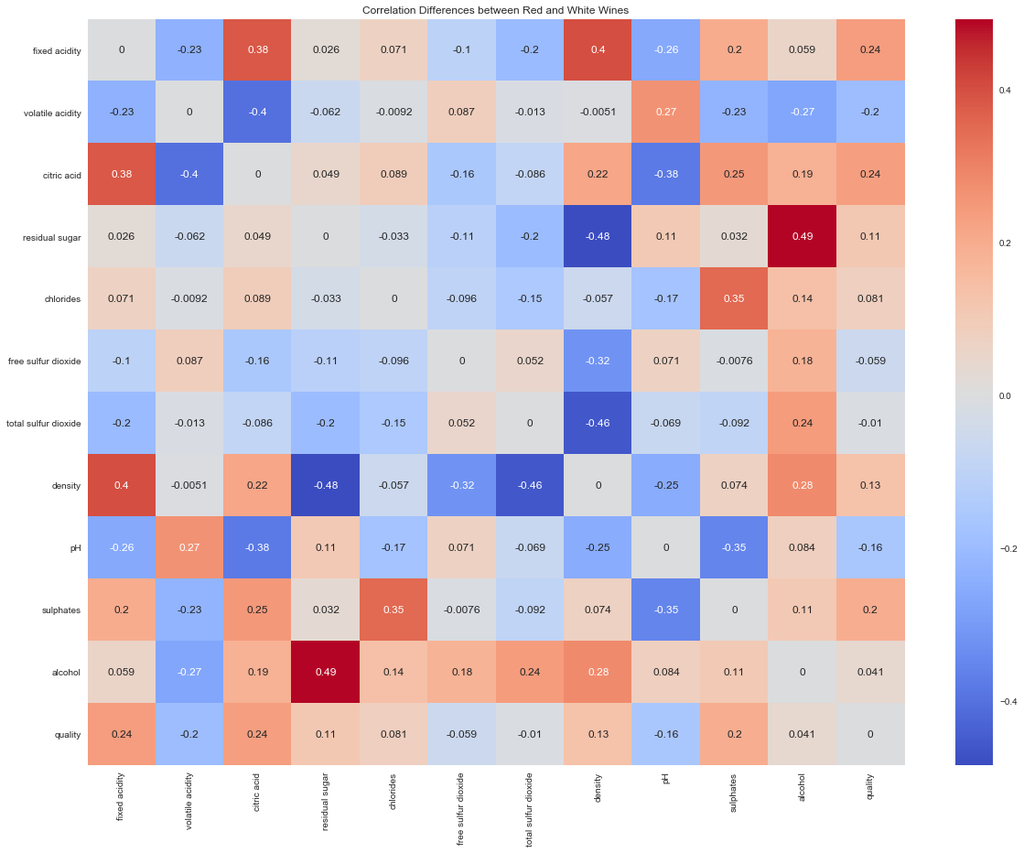

```python
corr_diff = corr_red - corr_white
plt.subplots(figsize=(20,15))
ax = plt.axes()
ax.set_title("Correlation Differences between Red and White Wines")
corr = corr_diff
sns.heatmap(corr,
            xticklabels=corr.columns.values,
            yticklabels=corr.columns.values,
           linecolor='white', cmap="coolwarm", annot=True)
plt.show()
```

Observations regarding Correlation Differences between Red and White Wines:

1. Alcohol and Residual Sugar are Highly positively correlated (0.49)
2. Density and Residual sugar are negatively Correlated (-0.48)
3. Density and Total sulfur dioxide are negatively Correlated (-0.46)
4. Density and fixed acidity are positively Correlated (0.4)
5. Citric acid and Volatile acidity are negatively Correlated (-0.40)
6. Fixed acidity and Citric acid are positively Correlated (0.38)
7. pH and Citric acid are negatively Correlated (-0.38)
8. Sulphates and Chlorides are positively Correlated (0.35)
9. Sulphates and pH are negatively Correlated (-0.35)
10. Density and free sulfur dioxide are negatively Correlated (-0.32)

[output not shown]

# 5. Model Building for Red Wine using Random Forest Classifier

Defining Target and features

```python
y = dataset_red.quality                  # set 'quality' as target
X = dataset_red.drop('quality', axis=1)  # rest other variables are features
print(y.shape, X.shape)
```

```
(1599,) (1599, 11)
```

```python
y1 = (y > 5).astype(int)
y1.head()
```

```
0    0
1    0
2    0
3    1
4    0
Name: quality, dtype: int32
```

```python
from sklearn.model_selection import train_test_split, cross_val_score
from sklearn.ensemble import RandomForestClassifier
from sklearn.metrics import accuracy_score, log_loss
from sklearn.metrics import confusion_matrix
```

Split data into training and test datasets

```python
seed = 8 # set seed for reproducibility
X_train, X_test, y_train, y_test = train_test_split(X, y1, test_size=0.2,
                                                    random_state=seed)

print(X_train.shape, X_test.shape, y_train.shape, y_test.shape)
```

```
(1279, 11) (320, 11) (1279,) (320,)
```

Train and evaluate the Random Forest Classifier with Cross Validation

```python
RF_clf = RandomForestClassifier(random_state=seed)
RF_clf
```

```
RandomForestClassifier(bootstrap=True, class_weight=None, criterion='gini',
            max_depth=None, max_features='auto', max_leaf_nodes=None,
            min_impurity_decrease=0.0, min_impurity_split=None,
            min_samples_leaf=1, min_samples_split=2,
            min_weight_fraction_leaf=0.0, n_estimators=10, n_jobs=1,
            oob_score=False, random_state=8, verbose=0, warm_start=False)
```

Compute k-fold cross validation on training dataset and see mean accuracy score

```python
cv_scores = cross_val_score(RF_clf,X_train, y_train, cv=10, scoring='accuracy')
print('The accuracy scores for the iterations are {}'.format(cv_scores))
print('The mean accuracy score is {}'.format(cv_scores.mean()))
```

```
The accuracy scores for the iterations are [ 0.82945736  0.78294574  0.81395349  0.796875    0.71875     0.703125
  0.78740157  0.77952756  0.7480315   0.82677165]
The mean accuracy score is 0.7786838872611854
```

Fitting the Random Forest Classifier on training set

```python
RF_clf.fit(X_train, y_train)
```

```
RandomForestClassifier(bootstrap=True, class_weight=None, criterion='gini',
            max_depth=None, max_features='auto', max_leaf_nodes=None,
            min_impurity_decrease=0.0, min_impurity_split=None,
            min_samples_leaf=1, min_samples_split=2,
            min_weight_fraction_leaf=0.0, n_estimators=10, n_jobs=1,
            oob_score=False, random_state=8, verbose=0, warm_start=False)
```

Predicting the Random Forest Classifier on test set

```python
pred_RF = RF_clf.predict(X_test)
```

# Accuracy, log loss and confusion matrix

```python
print(accuracy_score(y_test, pred_RF))
print(log_loss(y_test, pred_RF))
print(confusion_matrix(y_test, pred_RF))
```

```
0.79375
7.1236851
[[126  25]
 [ 41 128]]
```

# Hyperparameters Tuning of the Random Forest classifier using GridSearchCV

```python
from sklearn.model_selection import GridSearchCV
grid_values = {'n_estimators':[50,100,200],'max_depth':[None,30,15,5],
               'max_features':['auto','sqrt','log2'],'min_samples_leaf':[1,20,50,100]}
grid_RF = GridSearchCV(RF_clf,param_grid=grid_values,scoring='accuracy')
grid_RF.fit(X_train, y_train)
```

```
GridSearchCV(cv=None, error_score='raise',
       estimator=RandomForestClassifier(bootstrap=True, class_weight=None, criterion='gini',
            max_depth=None, max_features='auto', max_leaf_nodes=None,
            min_impurity_decrease=0.0, min_impurity_split=None,
            min_samples_leaf=1, min_samples_split=2,
            min_weight_fraction_leaf=0.0, n_estimators=10, n_jobs=1,
            oob_score=False, random_state=8, verbose=0, warm_start=False),
       fit_params=None, iid=True, n_jobs=1,
       param_grid={'n_estimators': [50, 100, 200], 'max_depth': [None, 30, 15, 5], 'max_features': ['auto', 'sqrt', 'log2'], 'min_samples_leaf': [1, 20, 50, 100]},
       pre_dispatch='2*n_jobs', refit=True, return_train_score='warn',
       scoring='accuracy', verbose=0)
```

Finding Best Parameters

```python
grid_RF.best_params_
```

```
{'max_depth': None,
 'max_features': 'auto',
 'min_samples_leaf': 1,
 'n_estimators': 100}
```

Other than number of estimators, the other recommended values are the defaults. Fitting the Random Forest Classifier on training set with Best Parameters.

```python
RF_clf = RandomForestClassifier(n_estimators=100,random_state=seed)
RF_clf.fit(X_train,y_train)
pred_RF = RF_clf.predict(X_test)
```

# Accuracy, log loss and confusion matrix after Hyperparameter Tuning

```python
print(accuracy_score(y_test,pred_RF))
print(log_loss(y_test,pred_RF))
print(confusion_matrix(y_test,pred_RF))
```

```
0.825
6.04434583892
[[127  24]
 [ 32 137]]
```

# 6. Model Building for White Wine using Random Forest Classifier

Defining Target and features

```python
y = dataset_white.quality                  # set 'quality' as target
X = dataset_white.drop('quality', axis=1)  # rest other variables are features
print(y.shape, X.shape)
```

```
(4898,) (4898, 11)
```

```python
y1 = (y > 5).astype(int)
y1.head()
```

```
0    1
1    1
2    1
3    1
4    1
Name: quality, dtype: int32
```

```python
from sklearn.model_selection import train_test_split, cross_val_score
from sklearn.ensemble import RandomForestClassifier
from sklearn.metrics import accuracy_score, log_loss
from sklearn.metrics import confusion_matrix
```

Split data into training and test datasets

```python
seed = 8 # set seed for reproducibility
X_train, X_test, y_train, y_test = train_test_split(X, y1, test_size=0.2,
                                                    random_state=seed)

print(X_train.shape, X_test.shape, y_train.shape, y_test.shape)
```

```
(3918, 11) (980, 11) (3918,) (980,)
```

Train and evaluate the Random Forest Classifier with Cross Validation

```python
RF_clf = RandomForestClassifier(random_state=seed)
RF_clf
```

```
RandomForestClassifier(bootstrap=True, class_weight=None, criterion='gini',
            max_depth=None, max_features='auto', max_leaf_nodes=None,
            min_impurity_decrease=0.0, min_impurity_split=None,
            min_samples_leaf=1, min_samples_split=2,
            min_weight_fraction_leaf=0.0, n_estimators=10, n_jobs=1,
            oob_score=False, random_state=8, verbose=0, warm_start=False)
```

Compute k-fold cross validation on training dataset and see mean accuracy score

```python
cv_scores = cross_val_score(RF_clf,X_train, y_train, cv=10, scoring='accuracy')
print('The accuracy scores for the iterations are {}'.format(cv_scores))
print('The mean accuracy score is {}'.format(cv_scores.mean()))
```

```
The accuracy scores for the iterations are [ 0.79898219  0.84438776  0.79846939  0.84183673  0.80357143  0.79591837
  0.82142857  0.79795396  0.79795396  0.84654731]
The mean accuracy score is 0.8147049676159878
```

Fitting the Random Forest Classifier on training set

```python
RF_clf.fit(X_train, y_train)
```

```
RandomForestClassifier(bootstrap=True, class_weight=None, criterion='gini',
            max_depth=None, max_features='auto', max_leaf_nodes=None,
            min_impurity_decrease=0.0, min_impurity_split=None,
            min_samples_leaf=1, min_samples_split=2,
            min_weight_fraction_leaf=0.0, n_estimators=10, n_jobs=1,
            oob_score=False, random_state=8, verbose=0, warm_start=False)
```

Predicting the Random Forest Classifier on test set

```python
pred_RF = RF_clf.predict(X_test)
```

# Accuracy, log loss and confusion matrix¶

```python
print(accuracy_score(y_test, pred_RF))
print(log_loss(y_test, pred_RF))
print(confusion_matrix(y_test, pred_RF))
```

```
0.822448979592
6.13246516132
[[243  86]
 [ 88 563]]
```

# Hyperparameters Tuning of the Random Forest classifier using GridSearchCV

```python
from sklearn.model_selection import GridSearchCV
grid_values = {'n_estimators':[50,100,200],'max_depth':[None,30,15,5],
               'max_features':['auto','sqrt','log2'],'min_samples_leaf':[1,20,50,100]}
grid_RF = GridSearchCV(RF_clf,param_grid=grid_values,scoring='accuracy')
grid_RF.fit(X_train, y_train)
```

```
GridSearchCV(cv=None, error_score='raise',
       estimator=RandomForestClassifier(bootstrap=True, class_weight=None, criterion='gini',
            max_depth=None, max_features='auto', max_leaf_nodes=None,
            min_impurity_decrease=0.0, min_impurity_split=None,
            min_samples_leaf=1, min_samples_split=2,
            min_weight_fraction_leaf=0.0, n_estimators=10, n_jobs=1,
            oob_score=False, random_state=8, verbose=0, warm_start=False),
       fit_params=None, iid=True, n_jobs=1,
       param_grid={'n_estimators': [50, 100, 200], 'max_depth': [None, 30, 15, 5], 'max_features': ['auto', 'sqrt', 'log2'], 'min_samples_leaf': [1, 20, 50, 100]},
       pre_dispatch='2*n_jobs', refit=True, return_train_score='warn',
       scoring='accuracy', verbose=0)
```

Finding Best Parameters

```python
grid_RF.best_params_
```

```
{'max_depth': None,
 'max_features': 'auto',
 'min_samples_leaf': 1,
 'n_estimators': 200}
```

Other than number of estimators, the other recommended values are the defaults. Fitting the Random Forest Classifier on training set with Best Parameters.

```python
RF_clf = RandomForestClassifier(n_estimators=200,random_state=seed)
RF_clf.fit(X_train,y_train)
pred_RF = RF_clf.predict(X_test)
```

# Accuracy, log loss and confusion matrix after Hyperparameter Tuning

```python
print(accuracy_score(y_test,pred_RF))
print(log_loss(y_test,pred_RF))
print(confusion_matrix(y_test,pred_RF))
```

```
0.838775510204
5.56857900994
[[228 101]
 [ 57 594]]
```